# Data Load

```python
import pandas as pd
info_data = pd.read_csv('https://storage.googleapis.com/datalynn-datasets/interview-challenge/technology/Zillow_Demand_Prediction/InfoData.csv')
```

# Question 1

A stakeholder is interested in understanding the effect of economic indicators on the listing price of properties. From the data provided, can you ascertain a relationship between the Economic_Indicator and the Listing_Price? Also, are there certain seasons where this relationship is stronger?

## Solution:

### Hints:

1. Utilize seaborn to create a scatter plot.
2. Investigate correlations between variables.
3. Utilize the groupby method for seasonal analysis.

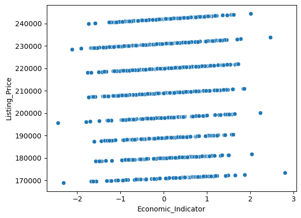

```
Correlation between Economic_Indicator and Listing_Price is 0.019649616834004187
Seasonal Correlations:
 Season
Fall      0.066452
Spring    0.034741
Summer    0.051677
Winter   -0.061829
dtype: float64
```

```python
import numpy as np
import matplotlib.pyplot as plt
import seaborn as sns

# Assuming info_data is loaded as a pandas DataFrame
# info_data = pd.read_csv('info_data.csv')

# 1. Visualizing the relationship between Economic_Indicator and Listing_Price
sns.scatterplot(data=info_data, x='Economic_Indicator', y='Listing_Price')
plt.show()

# 2. Checking the correlation
correlation = info_data['Economic_Indicator'].corr(info_data['Listing_Price'])
print(f"Correlation between Economic_Indicator and Listing_Price is {correlation}")

# 3. Analyzing the relationship seasonally
seasonal_data = info_data.groupby('Season').apply(lambda x: x['Economic_Indicator'].corr(x['Listing_Price']))
print("Seasonal Correlations:\n", seasonal_data)
```

# Question 2

Recently, there's been a discrepancy in the historical sale data. Using statistical methods, can you identify potential outliers or anomalies in the Historical_Sale data, especially when compared against the Economic_Indicator?

## Solution:

### Hints:

1. Calculate the Z-score for the Historical_Sale data.
2. Filter the data with Z-scores beyond a certain threshold.
3. Use a scatter plot to visualize the relationship with Economic_Indicator.

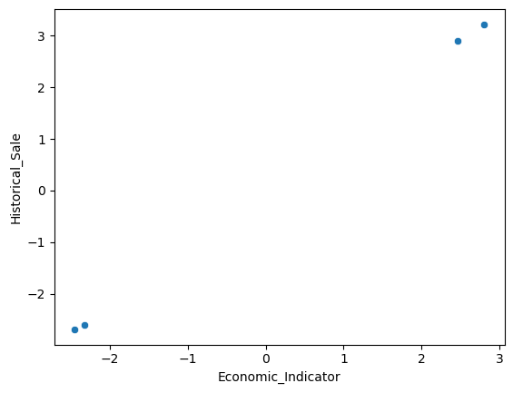

```python
from scipy import stats

# 1. Calculating the Z-score
info_data['Z_Score'] = np.abs(stats.zscore(info_data['Historical_Sale']))

# 2. Identifying outliers (e.g., Z-Score > 3)
outliers = info_data[info_data['Z_Score'] > 3]

# 3. Visualizing outliers
sns.scatterplot(data=outliers, x='Economic_Indicator', y='Historical_Sale')
plt.show()
```

# Question 3

Zillow wants to create a predictive model to forecast the Demand_Score for a property. Using the provided features, design a predictive model.

## Solution:

### Hints:

1. Perform feature selection and scaling.
2. Split data into training and testing sets.
3. Utilize Linear Regression and cross-validation to prevent overfitting.

```python
from sklearn.model_selection import train_test_split, cross_val_score
from sklearn.linear_model import LinearRegression
from sklearn.ensemble import RandomForestRegressor
from sklearn.metrics import mean_squared_error
from sklearn.preprocessing import StandardScaler

# 1. Drop rows with NaN values
info_data.dropna(subset=['Sale_Date', 'Listing_Date', 'Economic_Indicator', 'Historical_Sale', 'Listing_Price', 'Demand_Score'], inplace=True)

# 2. Transforming date features
info_data['Sale_Date'] = pd.to_datetime(info_data['Sale_Date'])
info_data['Listing_Date'] = pd.to_datetime(info_data['Listing_Date'])

info_data['Sale_Year'] = info_data['Sale_Date'].dt.year
info_data['Sale_Month'] = info_data['Sale_Date'].dt.month
info_data['Sale_Day'] = info_data['Sale_Date'].dt.day

info_data['Listing_Year'] = info_data['Listing_Date'].dt.year
info_data['Listing_Month'] = info_data['Listing_Date'].dt.month
info_data['Listing_Day'] = info_data['Listing_Date'].dt.day

# 3. Feature selection and scaling
features = ['Economic_Indicator', 'Historical_Sale', 'Listing_Price', 'Sale_Year', 'Sale_Month', 'Sale_Day', 'Listing_Year', 'Listing_Month', 'Listing_Day']
X = info_data[features]
y = info_data['Demand_Score']

scaler = StandardScaler()
X_scaled = scaler.fit_transform(X)

# 4. Data Splitting and Model Training
X_train, X_test, y_train, y_test = train_test_split(X_scaled, y, test_size=0.2, random_state=42)

model = LinearRegression()
cross_val_score(model, X_train, y_train, cv=5)
model.fit(X_train, y_train)

# Validation
y_pred = model.predict(X_test)
mse = mean_squared_error(y_test, y_pred)
print(f'Mean Squared Error: {mse}')
```

```
Mean Squared Error: 0.1747264281466577
```

# Question 4

Stakeholders have observed that properties in different regions (Rural or Urban) have varying demand scores. Can you perform a statistical test to determine if the mean Demand_Score is significantly different between the two Region_Type?

## Solution:

### Hints:

1. Use the groupby method to get means for each Region_Type.
2. Use a t-test to compare the means.
3. Interpret the p-value to draw conclusions.

```python
# 1. Calculating means for each Region_Type
mean_scores = info_data.groupby('Region_Type')['Demand_Score'].mean()
print(mean_scores)

# 2. T-Test
rural_scores = info_data[info_data['Region_Type'] == 'Rural']['Demand_Score']
urban_scores = info_data[info_data['Region_Type'] == 'Urban']['Demand_Score']
t_stat, p_value = stats.ttest_ind(rural_scores, urban_scores)

# 3. Interpretation
if p_value < 0.05:
    print("The means are statistically different.")
else:
    print("The means are not statistically different.")
```

```
Region_Type
Rural    55.323363
Urban    56.279525
Name: Demand_Score, dtype: float64
The means are not statistically different.
```